# Assignment 2

1. (1pt) Download the dataset and store it in a dataframe in R. The dataset does not have header, you should add the headers manually to your dataframe based on the list of attributes provided in https://archive.ics.uci.edu/ml/datasets/Adult. Also please note that some entries have extra white space. So to read the data properly, use the option strip.white=TRUE in read.csv function.

```r
adult_df = read.csv("adult.data",header = FALSE,strip.white = TRUE, stringsAsFactors = TRUE,col.names = c("age","workclass","fnlwgt","education","education-num","marital-status","occupation",
                                                                                "relationship","race","sex","capital-gain","capital-loss","hours-per-week","native-country","income"))
```

2. (1pt) Explore the overall structure of the dataset using the str() function. Get a summary statistics of each variable. How many categorical and numeric variables you have in your data? Is there any missing values?

```r
str(adult_df)
```

```
'data.frame':   32561 obs. of  15 variables:
 $ age           : int  39 50 38 53 28 37 49 52 31 42 ...
 $ workclass     : Factor w/ 9 levels "?","Federal-gov",..: 8 7 5 5 5 5 5 7 5 5 ...
 $ fnlwgt        : int  77516 83311 215646 234721 338409 284582 160187 209642 45781 159449 ...
 $ education     : Factor w/ 16 levels "10th","11th",..: 10 10 12 2 10 13 7 12 13 10 ...
 $ education.num : int  13 13 9 7 13 14 5 9 14 13 ...
 $ marital.status: Factor w/ 7 levels "Divorced","Married-AF-spouse",..: 5 3 1 3 3 3 4 3 5 3 ...
 $ occupation    : Factor w/ 15 levels "?","Adm-clerical",..: 2 5 7 7 11 5 9 5 11 5 ...
 $ relationship  : Factor w/ 6 levels "Husband","Not-in-family",..: 2 1 2 1 6 6 2 1 2 1 ...
 $ race          : Factor w/ 5 levels "Amer-Indian-Eskimo",..: 5 5 5 3 3 5 3 5 5 5 ...
 $ sex           : Factor w/ 2 levels "Female","Male": 2 2 2 2 1 1 1 2 1 2 ...
 $ capital.gain  : int  2174 0 0 0 0 0 0 0 14084 5178 ...
 $ capital.loss  : int  0 0 0 0 0 0 0 0 0 0 ...
 $ hours.per.week: int  40 13 40 40 40 40 16 45 50 40 ...
 $ native.country: Factor w/ 42 levels "?","Cambodia",..: 40 40 40 40 6 40 24 40 40 40 ...
 $ income        : Factor w/ 2 levels "<=50K",">50K": 1 1 1 1 1 1 1 2 2 2 ...
```

There are nine categorical variables and six numeric variables in the data set.

```r
summary(adult_df$age)
```

```
   Min. 1st Qu.  Median    Mean 3rd Qu.    Max.
  17.00   28.00   37.00   38.58   48.00   90.00
```

```r
summary(adult_df$workclass)
```

```
               ?      Federal-gov        Local-gov     Never-worked          Private     Self-emp-inc Self-emp-not-inc        State-gov      Without-pay
            1836              960             2093                7            22696             1116             2541             1298               14
```

```r
summary(adult_df$fnlwgt)
```

```
   Min. 1st Qu.  Median    Mean 3rd Qu.    Max.
  12285  117827  178356  189778  237051 1484705
```

```r
summary(adult_df$education)
```

```
        10th         11th         12th      1st-4th      5th-6th      7th-8th          9th   Assoc-acdm    Assoc-voc    Bachelors    Doctorate      HS-grad      Masters    Preschool
         933         1175          433          168          333          646          514         1067         1382         5355          413        10501         1723           51
 Prof-school Some-college
         576         7291
```

```r
summary(adult_df$education.num)
```

```
   Min. 1st Qu.  Median    Mean 3rd Qu.    Max.
   1.00    9.00   10.00   10.08   12.00   16.00
```

```r
summary(adult_df$marital.status)
```

```
             Divorced     Married-AF-spouse    Married-civ-spouse Married-spouse-absent         Never-married             Separated               Widowed
                 4443                    23                 14976                   418                 10683                  1025                   993
```

```r
summary(adult_df$occupation)
```

```
                ?      Adm-clerical      Armed-Forces      Craft-repair   Exec-managerial   Farming-fishing Handlers-cleaners Machine-op-inspct     Other-service   Priv-house-serv
             1843              3770                 9              4099              4066               994              1370              2002              3295               149
   Prof-specialty   Protective-serv             Sales      Tech-support  Transport-moving
             4140               649              3650               928              1597
```

```r
summary(adult_df$relationship)
```

```
       Husband  Not-in-family Other-relative      Own-child      Unmarried           Wife
         13193           8305            981           5068           3446           1568
```

```r
summary(adult_df$race)
```

```
Amer-Indian-Eskimo Asian-Pac-Islander              Black              Other              White
               311               1039               3124                271              27816
```

```r
summary(adult_df$sex)
```

```
Female   Male
 10771  21790
```

```r
summary(adult_df$capital.gain)
```

```
   Min. 1st Qu.  Median    Mean 3rd Qu.    Max.
      0       0       0    1078       0   99999
```

```r
summary(adult_df$capital.loss)
```

```
   Min. 1st Qu.  Median    Mean 3rd Qu.    Max.
    0.0     0.0     0.0    87.3     0.0  4356.0
```

```r
summary(adult_df$hours.per.week)
```

```
   Min. 1st Qu.  Median    Mean 3rd Qu.    Max.
   1.00   40.00   40.00   40.44   45.00   99.00
```

```r
summary(adult_df$native.country)
```

```
                         ?                   Cambodia                     Canada                      China                   Columbia                       Cuba
                       583                         19                        121                         75                         59                         95
        Dominican-Republic                    Ecuador                El-Salvador                    England                     France                    Germany
                        70                         28                        106                         90                         29                        137
                    Greece                  Guatemala                      Haiti         Holand-Netherlands                   Honduras                       Hong
                        29                         64                         44                          1                         13                         20
                   Hungary                      India                       Iran                    Ireland                      Italy                    Jamaica
                        13                        100                         43                         24                         73                         81
                     Japan                       Laos                     Mexico                  Nicaragua Outlying-US(Guam-USVI-etc)                       Peru
                        62                         18                        643                         34                         14                         31
               Philippines                     Poland                   Portugal                Puerto-Rico                   Scotland                      South
                       198                         60                         37                        114                         12                         80
                    Taiwan                   Thailand            Trinadad&Tobago              United-States                    Vietnam                 Yugoslavia
                        51                         18                         19                      29170                         67                         16
```

```r
summary(adult_df$income)
```

```
<=50K  >50K
24720  7841
```

3. (1pt) Get the frequency table of the “income” variable to see how many observations you have in each category of the income variable. Is the data balanced? Do we have equal number of samples in each class of income?

```r
inc_table = table(adult_df$income)
inc_table
```

```
<=50K  >50K
24720  7841
```

```r
round(prop.table(inc_table) * 100, digits = 2)
```

```
<=50K  >50K
75.92 24.08
```

The data is skewed heavily to the <=50k with that class making up 76% of all entries

4. (3 pts) Explore the data in order to investigate the association between income and the other features. Which of the other features seem most likely to be useful in predicting income.

4a. To explore the relationship between numerical features and “income” variable, you can use side by side box plot and t.test

```r
attach(adult_df)
```

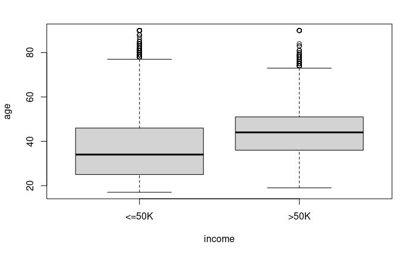

```r
boxplot(age~income)
```

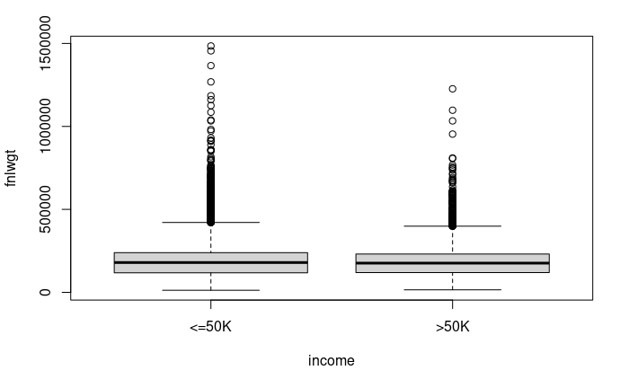

```r
boxplot(fnlwgt~income)
```

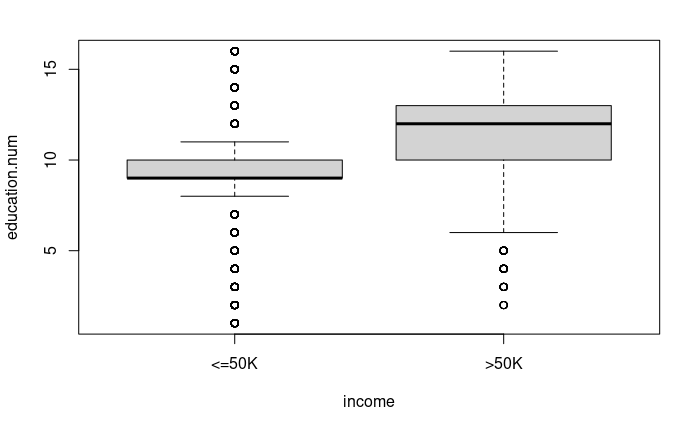

```r
boxplot(education.num~income)
```

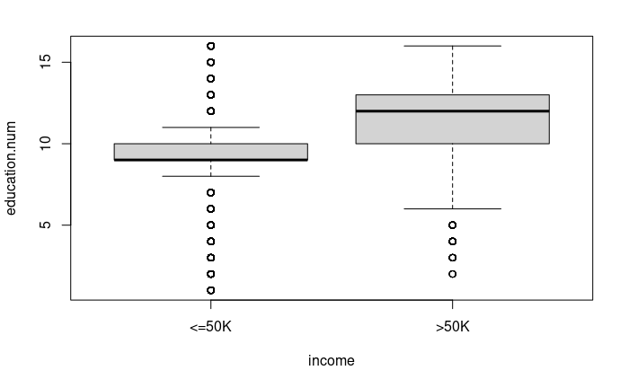

```r
boxplot(education.num~income)
```

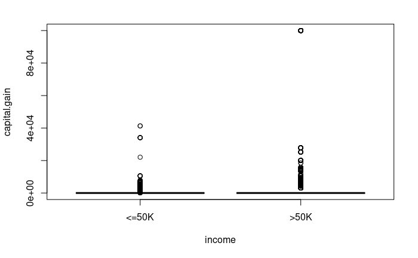

```r
boxplot(capital.gain~income)
```

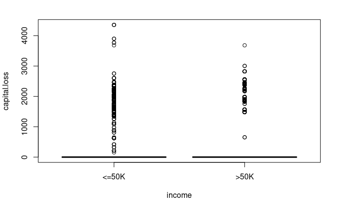

```r
boxplot(capital.loss~income)
```

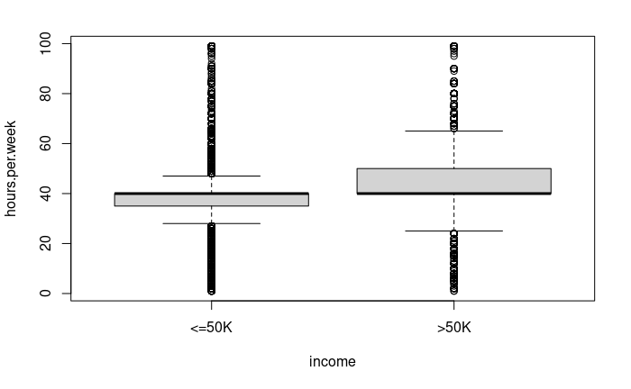

```r
boxplot(hours.per.week~income)
```

```r
t.test(age~income)
```

```
    Welch Two Sample t-test

data:  age by income
t = -50.264, df = 17411, p-value < 2.2e-16
alternative hypothesis: true difference in means is not equal to 0
95 percent confidence interval:
 -7.757250 -7.174955
sample estimates:
mean in group <=50K  mean in group >50K
           36.78374            44.24984
```

```r
t.test(fnlwgt~income)
```

```
    Welch Two Sample t-test

data:  fnlwgt by income
t = 1.7412, df = 13615, p-value = 0.08167
alternative hypothesis: true difference in means is not equal to 0
95 percent confidence interval:
 -293.7029 4965.4332
sample estimates:
mean in group <=50K  mean in group >50K
           190340.9            188005.0
```

```r
t.test(education.num~income)
```

```
    Welch Two Sample t-test

data:  education.num by income
t = -64.896, df = 13421, p-value < 2.2e-16
alternative hypothesis: true difference in means is not equal to 0
95 percent confidence interval:
 -2.077502 -1.955682
sample estimates:
mean in group <=50K  mean in group >50K
           9.595065           11.611657
```

```r
t.test(capital.gain~income)
```

```
    Welch Two Sample t-test

data:  capital.gain by income
t = -23.427, df = 7861.7, p-value < 2.2e-16
alternative hypothesis: true difference in means is not equal to 0
95 percent confidence interval:
 -4180.166 -3534.614
sample estimates:
mean in group <=50K  mean in group >50K
           148.7525           4006.1425
```

```r
t.test(capital.loss~income)
```

```
    Welch Two Sample t-test

data:  capital.loss by income
t = -20.238, df = 9231.1, p-value < 2.2e-16
alternative hypothesis: true difference in means is not equal to 0
95 percent confidence interval:
 -155.5985 -128.1187
sample estimates:
mean in group <=50K  mean in group >50K
           53.14292           195.00153
```

```r
t.test(hours.per.week~income)
```

```
    Welch Two Sample t-test

data:  hours.per.week by income
t = -45.123, df = 14570, p-value < 2.2e-16
alternative hypothesis: true difference in means is not equal to 0
95 percent confidence interval:
 -6.920943 -6.344690
sample estimates:
mean in group <=50K  mean in group >50K
           38.84021            45.47303
```

For the numerical features it would appear that there is a relationship between income and the following: age, education-num, capitol-gain, capitol-loss, and hours-per-week

```r
adult_df_old = adult_df
adult_df = adult_df[-3]
```

4b. To explore the relationship between categorical features and “income” variable, you can use frequency table and chisquare test (note that chisquare test might throw a warning if there are cells whose expected counts in the frequency table is less 5. This warning means the p-values reported from chisquare test may be incorrect due to low counts and are not reliable. You can ignore the warning for this assignment).

```r
workclass_tbl = table(workclass, income)
workclass_tbl
```

```
                  income
workclass          <=50K  >50K
  ?                 1645   191
  Federal-gov        589   371
  Local-gov         1476   617
  Never-worked         7     0
  Private          17733  4963
  Self-emp-inc       494   622
  Self-emp-not-inc  1817   724
  State-gov          945   353
  Without-pay         14     0
```

```r
chisq.test(workclass_tbl)
```

```
Chi-squared approximation may be incorrect
```

```
    Pearson's Chi-squared test

data:  workclass_tbl
X-squared = 1045.7, df = 8, p-value < 2.2e-16
```

```r
marital.status_tbl = table(marital.status, income)
marital.status_tbl
```

```
                       income
marital.status          <=50K  >50K
  Divorced               3980   463
  Married-AF-spouse        13    10
  Married-civ-spouse     8284  6692
  Married-spouse-absent   384    34
  Never-married         10192   491
  Separated               959    66
  Widowed                 908    85
```

```r
chisq.test(marital.status_tbl)
```

```
    Pearson's Chi-squared test

data:  marital.status_tbl
X-squared = 6517.7, df = 6, p-value < 2.2e-16
```

```r
education_tbl = table(education, income)
education_tbl
```

```
              income
education      <=50K >50K
  10th           871   62
  11th          1115   60
  12th           400   33
  1st-4th        162    6
  5th-6th        317   16
  7th-8th        606   40
  9th            487   27
  Assoc-acdm     802  265
  Assoc-voc     1021  361
  Bachelors     3134 2221
  Doctorate      107  306
  HS-grad       8826 1675
  Masters        764  959
  Preschool       51    0
  Prof-school    153  423
  Some-college  5904 1387
```

```r
chisq.test(education_tbl)
```

```
    Pearson's Chi-squared test

data:  education_tbl
X-squared = 4429.7, df = 15, p-value < 2.2e-16
```

```r
occupation_tbl = table(occupation, income)
occupation_tbl
```

```
                   income
occupation          <=50K >50K
  ?                  1652  191
  Adm-clerical       3263  507
  Armed-Forces          8    1
  Craft-repair       3170  929
  Exec-managerial    2098 1968
  Farming-fishing     879  115
  Handlers-cleaners  1284   86
  Machine-op-inspct  1752  250
  Other-service      3158  137
  Priv-house-serv     148    1
  Prof-specialty     2281 1859
  Protective-serv     438  211
  Sales              2667  983
  Tech-support        645  283
  Transport-moving   1277  320
```

```r
chisq.test(occupation_tbl)
```

```
Chi-squared approximation may be incorrect
```

```
    Pearson's Chi-squared test

data:  occupation_tbl
X-squared = 4032, df = 14, p-value < 2.2e-16
```

```r
relationship_tbl = table(relationship, income)
relationship_tbl
```

```
                income
relationship     <=50K >50K
  Husband         7275 5918
  Not-in-family   7449  856
  Other-relative   944   37
  Own-child       5001   67
  Unmarried       3228  218
  Wife             823  745
```

```r
chisq.test(relationship_tbl)
```

```
    Pearson's Chi-squared test

data:  relationship_tbl
X-squared = 6699.1, df = 5, p-value < 2.2e-16
```

```r
sex_tbl = table(sex, income)
sex_tbl
```

```
        income
sex      <=50K  >50K
  Female  9592  1179
  Male   15128  6662
```

```r
chisq.test(sex_tbl)
```

```
    Pearson's Chi-squared test with Yates' continuity correction

data:  sex_tbl
X-squared = 1517.8, df = 1, p-value < 2.2e-16
```

```r
native.country_tbl = table(native.country, income)
native.country_tbl
```

```
                            income
native.country               <=50K  >50K
  ?                              0     0
  Cambodia                      12     7
  Canada                        82    39
  China                         55    20
  Columbia                      57     2
  Cuba                          70    25
  Dominican-Republic            68     2
  Ecuador                       24     4
  El-Salvador                   97     9
  England                       60    30
  France                        17    12
  Germany                       93    44
  Greece                        21     8
  Guatemala                     61     3
  Haiti                         40     4
  Holand-Netherlands             1     0
  Honduras                      12     1
  Hong                          14     6
  Hungary                       10     3
  India                         60    40
  Iran                          25    18
  Ireland                       19     5
  Italy                         48    25
  Jamaica                       71    10
  Japan                         38    24
  Laos                          16     2
  Mexico                       610    33
  Nicaragua                     32     2
  Outlying-US(Guam-USVI-etc)    14     0
  Peru                          29     2
  Philippines                  137    61
  Poland                        48    12
  Portugal                      33     4
  Puerto-Rico                  102    12
  Scotland                       9     3
  South                         64    16
  Taiwan                        31    20
  Thailand                      15     3
  Trinadad&Tobago               17     2
  United-States              21999  7171
  Vietnam                       62     5
  Yugoslavia                    10     6
```

```r
chisq.test(native.country_tbl[-1]) #to remove "?" from the factor since it breaks the chi-squared test
```

```
    Chi-squared test for given probabilities

data:  native.country_tbl[-1]
X-squared = 1358905, df = 82, p-value < 2.2e-16
```

4c. Based on your data exploration above, decide which attributes you are going to use to predict income. Explain your reason for selecting these attributes.

I’m using the following attributes because I have shown that there is a statistically significant relationship between them and income: relationship, workclass, marital-status, education, occupation, sex, native-country, age, education-num, capitol-gain, capitol-loss, and hours-per-week

5. (1 pt) An initial data exploration shows that the missing values in the dataset are denoted by “?” not NA. Change all the “?” characters in the dataframe to NA

```r
adult_df[adult_df == "?"] <- NA
```

6. (1pt) Use the command colSums(is.na() to get the number of missing values in each column of your dataframe. Which columns have missing values?

```r
colSums(is.na(adult_df))
```

```
           age      workclass      education  education.num marital.status     occupation   relationship           race            sex   capital.gain   capital.loss hours.per.week
             0           1836              0              0              0           1843              0              0              0              0              0              0
native.country         income
           583              0
```

workclass, occupation and native.country have missing values

7. (3 pt) There are several ways we can deal with missing values. The easiest approach is to remove all the rows with missing values. However, if a large number of rows have missing values removing them will result in loss of information and may affect the classifier performance. If a large number of rows have missing values, then it is typically better to replace missing data with some values. This is called data imputation. Several methods for missing data imputation exist. The most naïve method (which we will use here) is to replace the missing values with mean of the column (for a numerical column) or mode/majority value of the column (for a categorical column). We will use a more advanced data imputation method in a later module. For now, replace the missing values in a numerical column with the mean of the column and the missing values in a categorical column with the mode/majority of the column. After imputation, use colSums(is.na() to make sure that your dataframe no longer has missing values

```r
Mode <- function(x) {
  ux <- unique(x)
  ux[which.max(tabulate(match(x, ux)))]
}
```

```r
adult_df$workclass[is.na(adult_df$workclass)] = Mode(adult_df$workclass)
adult_df$occupation[is.na(adult_df$occupation)] = Mode(adult_df$occupation)
adult_df$native.country[is.na(adult_df$native.country)] = Mode(adult_df$native.country)
```

```r
colSums(is.na(adult_df))
```

```
           age      workclass      education  education.num marital.status     occupation   relationship           race            sex   capital.gain   capital.loss hours.per.week
             0              0              0              0              0              0              0              0              0              0              0              0
native.country         income
             0              0
```

8. (2 pt) This dataset has several categorical variables. With the exception of few models ( such as Naiive Bayes and tree-based models) most machine learning models require numeric features and cannot work directly with categorical data. One way to deal with categorical variables is to assign numeric indices to each level. However, this imposes an artificial ordering on an unordered categorical variable. For example, suppose that we have a categorical variable primary color with three levels: “red”,”blue”,”green”. If we convert “red” to 0 , “blue” to 1 and “green” to 2 then we are telling our model that red < blue< green which is not correct. A better way to encode an unordered categorical variable is to do one-hot-encoding. In one hot-encoding we create a dummy binary variable for each level of a categorical variable. For example we can represent the primary color variable by three binary dummy variables, one for each color (red, blue, and green) . If the color is red, then the variable red takes value 1 while blue and green both take the value zero.

Do one-hot-encoding of all your unordered categorical variables (except the income variable). You can use the function one_hot from mltools package to one-hot encode all categorical variables in a dataset. Please refer to https://rdrr.io/cran/mltools/man/one_hot.html . Use option DropUnusedLevels=True to avoid creating a binary variable for unused levels of a factor variable.

Please note that the one_hot function takes a data table not a dataframe. You can convert a dataframe to datatable by using as.data.table method https://www.rdocumentation.org/packages/data.table/versions/1.12.8/topics/as.data.table. Make sure to use library(data.table) before using as.data.table method. You can covert a datatable back to a dataframe by using as.data.frame method https://www.rdocumentation.org/packages/base/versions/3.6.2/topics/as.data.frame

```r
#install.packages("mltools")
library(mltools)
library(data.table)
```

```r
encoded_table = one_hot(data.table(adult_df[,-which(names(adult_df) == "income")]), dropUnusedLevels = TRUE)
encoded_df = as.data.frame(encoded_table)
encoded_df$income = adult_df$income
names(encoded_df)
```

```
  [1] "age"                                       "workclass_Federal-gov"                     "workclass_Local-gov"                       "workclass_Never-worked"
  [5] "workclass_Private"                         "workclass_Self-emp-inc"                    "workclass_Self-emp-not-inc"                "workclass_State-gov"
  [9] "workclass_Without-pay"                     "education_10th"                            "education_11th"                            "education_12th"
 [13] "education_1st-4th"                         "education_5th-6th"                         "education_7th-8th"                         "education_9th"
 [17] "education_Assoc-acdm"                      "education_Assoc-voc"                       "education_Bachelors"                       "education_Doctorate"
 [21] "education_HS-grad"                         "education_Masters"                         "education_Preschool"                       "education_Prof-school"
 [25] "education_Some-college"                    "education.num"                             "marital.status_Divorced"                   "marital.status_Married-AF-spouse"
 [29] "marital.status_Married-civ-spouse"         "marital.status_Married-spouse-absent"      "marital.status_Never-married"              "marital.status_Separated"
 [33] "marital.status_Widowed"                    "occupation_Adm-clerical"                   "occupation_Armed-Forces"                   "occupation_Craft-repair"
 [37] "occupation_Exec-managerial"                "occupation_Farming-fishing"                "occupation_Handlers-cleaners"              "occupation_Machine-op-inspct"
 [41] "occupation_Other-service"                  "occupation_Priv-house-serv"                "occupation_Prof-specialty"                 "occupation_Protective-serv"
 [45] "occupation_Sales"                          "occupation_Tech-support"                   "occupation_Transport-moving"               "relationship_Husband"
 [49] "relationship_Not-in-family"                "relationship_Other-relative"               "relationship_Own-child"                    "relationship_Unmarried"
 [53] "relationship_Wife"                         "race_Amer-Indian-Eskimo"                   "race_Asian-Pac-Islander"                   "race_Black"
 [57] "race_Other"                                "race_White"                                "sex_Female"                                "sex_Male"
 [61] "capital.gain"                              "capital.loss"                              "hours.per.week"                            "native.country_Cambodia"
 [65] "native.country_Canada"                     "native.country_China"                      "native.country_Columbia"                   "native.country_Cuba"
 [69] "native.country_Dominican-Republic"         "native.country_Ecuador"                    "native.country_El-Salvador"                "native.country_England"
 [73] "native.country_France"                     "native.country_Germany"                    "native.country_Greece"                     "native.country_Guatemala"
 [77] "native.country_Haiti"                      "native.country_Holand-Netherlands"         "native.country_Honduras"                   "native.country_Hong"
 [81] "native.country_Hungary"                    "native.country_India"                      "native.country_Iran"                       "native.country_Ireland"
 [85] "native.country_Italy"                      "native.country_Jamaica"                    "native.country_Japan"                      "native.country_Laos"
 [89] "native.country_Mexico"                     "native.country_Nicaragua"                  "native.country_Outlying-US(Guam-USVI-etc)" "native.country_Peru"
 [93] "native.country_Philippines"                "native.country_Poland"                     "native.country_Portugal"                   "native.country_Puerto-Rico"
 [97] "native.country_Scotland"                   "native.country_South"                      "native.country_Taiwan"                     "native.country_Thailand"
[101] "native.country_Trinadad&Tobago"            "native.country_United-States"              "native.country_Vietnam"                    "native.country_Yugoslavia"
[105] "income"
```

9. Set the seed of the random number generator to a fixed integer, say 1, so that I can reproduce your work:

```r
set.seed(1)
```

10. (1 pt) Scale all numeric features using Min-Max scaling

```r
normalize = function(col){
    (col - min(col))/(max(col) - min(col))
}
normalized_df = as.data.frame(sapply(encoded_df[-(length(encoded_df))], normalize))
```

11. (1pt) Randomize the order of the rows in the dataset.

```r
encoded_df = encoded_df[sample(nrow(encoded_df),replace = FALSE),]
normalized_df = as.data.frame(sapply(encoded_df[-(length(encoded_df))], normalize))
```

12. (4 pts) Use 5-fold cross validation with KNN to predict the “income” variable and report the cross- validation error. ( You can find an example in slides 51-53 of module 4 lecture notes).

```r
library(lattice)
library(ggplot2)
library(caret)
library(class)
```